# Making maps of Italy with R part 1

Cynthia Anstey

2024-08-28

### dati sorigente

###### italiano

Dati sorgente

I file contenuti in questo archivio sono derivati dai dati di OpenStreetMap e sono distribuiti sotto la Licenza Open Database 1.0. Per maggiori informazioni sul progetto, visita www.openstreetmap.org.

Questo file contiene dati di OpenStreetMap aggiornati al 2024-08-23T20:21:17Z. Ogni giorno verrà resa disponibile una nuova versione di questo file al seguente link:

http://download.geofabrik.de/europe/italy/centro-latest-free.shp.zip

Una documentazione sui livelli di questo shapefile è disponibile qui:

http://download.geofabrik.de/osm-data-in-gis-formats-free.pdf

Ci sono 17 file .shp all’interno del file zip scaricato al 27-08-2024. Ho selezionato un file che si chiama “places” e “free”, sperando che la struttura fosse adatta per esercitarmi.

### source data

###### english

The files in this archive are derived from OpenStreetMap data and are licensed under the Open Database 1.0 License. For more details, visit OpenStreetMap.

- **File link**: [Download Shapefile](http://download.geofabrik.de/europe/italy/centro-latest-free.shp.zip)
- **Documentation**: [Layer Documentation](http://download.geofabrik.de/osm-data-in-gis-formats-free.pdf)

### resources

Cookbooks that helped the learning process.

Risorse che hanno supportato il processo di apprendimento.

- [ggplot2 and sf integration](https://r-spatial.org/r/2018/10/25/ggplot2-sf.html)
- [Shapefile](https://r-graphics.org/recipe-miscgraph-map-shapefile)
- [advanced mapping](https://bookdown.org/robinlovelace/geocompr/adv-map.html)

### purpose

Practical exercise using ggplot and layering data from two .shp files designated as centro Italia. Esercizio pratico che utilizza `ggplot` e sovrappone i dati di due file .shp etichettati come “centro Italia”.

### Install Libraries

```r
library("ggplot2")
theme_set(theme_bw())
library("sf")
library("dplyr")
```

### Load Data

```r
#After importing a file, use st_read to read it into R.
italy_shp <- st_read("C:\\Users\\Public\\Downloads\\centro-latest-free.shp\\gis_osm_places_free_1.shp")
```

### Quick Inspection

‘italy_shp’ examined using a tibble and ‘italy_shp1’ reviewed with str.

Il file `italy_shp` viene analizzato con un tibble, mentre `italy_shp1` è esaminato utilizzando la funzione `str`.

```r
italy_shp1 <- st_read("C:\\Users\\Public\\Downloads\\centro-latest-free.shp\\gis_osm_places_a_free_1.shp")
str(italy_shp)
```

```
## Classes 'sf' and 'data.frame':   22941 obs. of  6 variables:
##  $ osm_id    : chr  "31120673" "33374771" "36159460" "36159465" ...
##  $ code      : int  1004 1004 1050 1050 1050 1004 1004 1004 1004 1004 ...
##  $ fclass    : chr  "hamlet" "hamlet" "locality" "locality" ...
##  $ population: num  0 0 0 0 0 211 0 0 0 0 ...
##  $ name      : chr  "Montechiaro" "Moraduccio" "Punta del Casotto" "Punta della Gallina" ...
##  $ geometry  :sfc_POINT of length 22941; first list element:  'XY' num  11.4 43.3
##  - attr(*, "sf_column")= chr "geometry"
##  - attr(*, "agr")= Factor w/ 3 levels "constant","aggregate",..: NA NA NA NA NA
##   ..- attr(*, "names")= chr [1:5] "osm_id" "code" "fclass" "population" ...
```

```r
str(italy_shp1)
```

```
## Classes 'sf' and 'data.frame':   527 obs. of  6 variables:
##  $ osm_id    : chr  "24321518" "27129378" "31231951" "34019084" ...
##  $ code      : int  1020 1020 1020 1010 1010 1010 1010 1010 1010 1010 ...
##  $ fclass    : chr  "island" "island" "island" "suburb" ...
##  $ population: num  0 0 0 0 0 0 0 0 0 0 ...
##  $ name      : chr  "Isola Zannone" "Isola di Pianosa" "Palmarola" "Cappuccini" ...
##  $ geometry  :sfc_MULTIPOLYGON of length 527; first list element: List of 1
##   ..$ :List of 1
##   .. ..$ : num [1:159, 1:2] 13 13 13 13 13 ...
##   ..- attr(*, "class")= chr [1:3] "XY" "MULTIPOLYGON" "sfg"
##  - attr(*, "sf_column")= chr "geometry"
##  - attr(*, "agr")= Factor w/ 3 levels "constant","aggregate",..: NA NA NA NA NA
##   ..- attr(*, "names")= chr [1:5] "osm_id" "code" "fclass" "population" ...
```

```r
tibble(italy_shp)
```

```
## # A tibble: 22,941 × 6
##    osm_id    code fclass   population name                        geometry
##    <chr>    <int> <chr>         <dbl> <chr>                    <POINT [°]>
##  1 31120673  1004 hamlet            0 Montechiaro      (11.40474 43.33198)
##  2 33374771  1004 hamlet            0 Moraduccio        (11.4877 44.17534)
##  3 36159460  1050 locality          0 Punta del Casot… (10.32821 43.48488)
##  4 36159465  1050 locality          0 Punta della Gal…  (10.3301 43.47412)
##  5 36159469  1050 locality          0 Punta Pacchiano  (10.33704 43.46837)
##  6 37620144  1004 hamlet          211 Monte Petriolo    (12.22759 43.0161)
##  7 56018975  1004 hamlet            0 Sant'Apollinare   (11.5877 44.16221)
##  8 56018980  1004 hamlet            0 Misileo          (11.58803 44.16046)
##  9 56018981  1004 hamlet            0 Badia di Susina… (11.57582 44.14068)
## 10 56040321  1004 hamlet            0 Coniale          (11.45693 44.15242)
## # ℹ 22,931 more rows
```

### Plot Data

Use ggplot give the file a geometric simple form (sf). italy_shp is plotted first then italy_shp1.

Con `ggplot`, visualizza i file come geometrie semplici (sf). Prima viene creato il grafico per `italy_shp`, seguito da quello per `italy_shp1`.

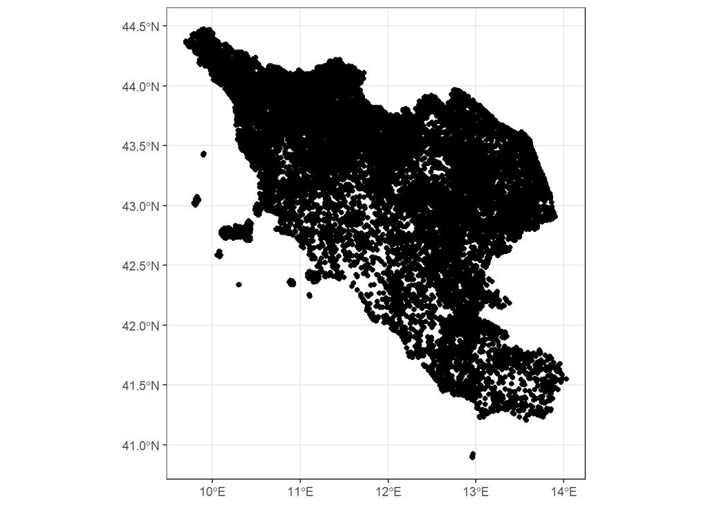

```r
# Plot the first shapefile
ggplot(italy_shp)+
geom_sf()
```

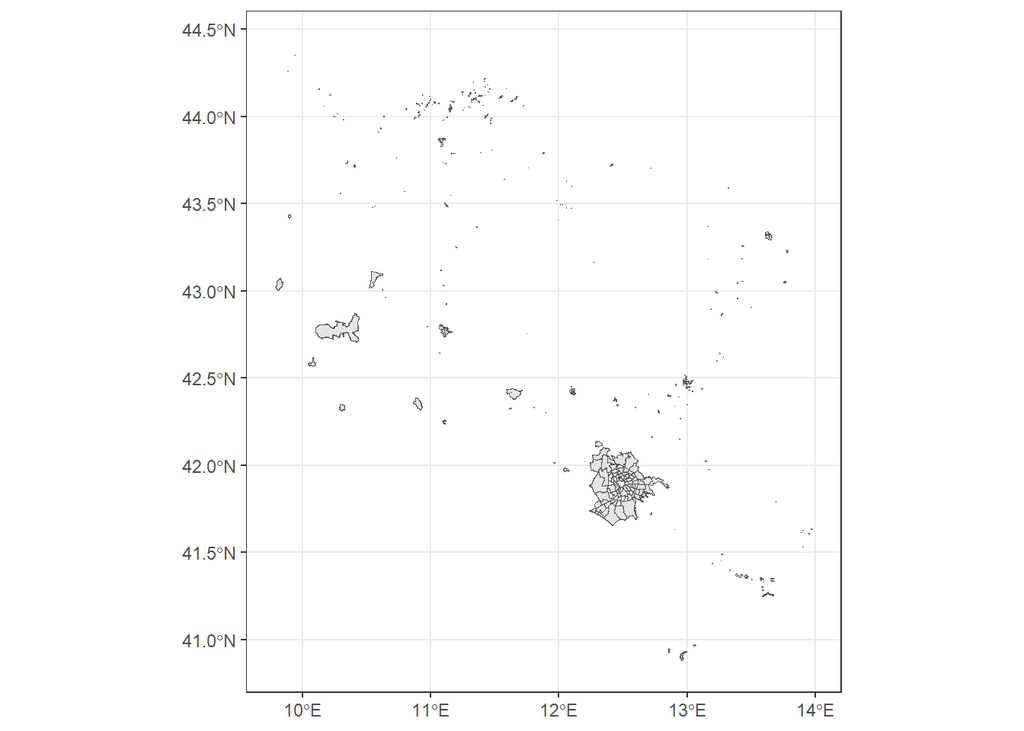

```r
# Plot the second shapefile
ggplot(italy_shp1)+
geom_sf()
```

### Layered Maps The following code layers both spatial plots. The selected file, labeled as “Centro,” includes geometric points that indicate locations considered central in Italy. Il codice sottostante sovrappone i due grafici spaziali. Il file selezionato, contrassegnato come “Centro,” mostra punti geometrici che rappresentano località ritenute centrali in Italia.

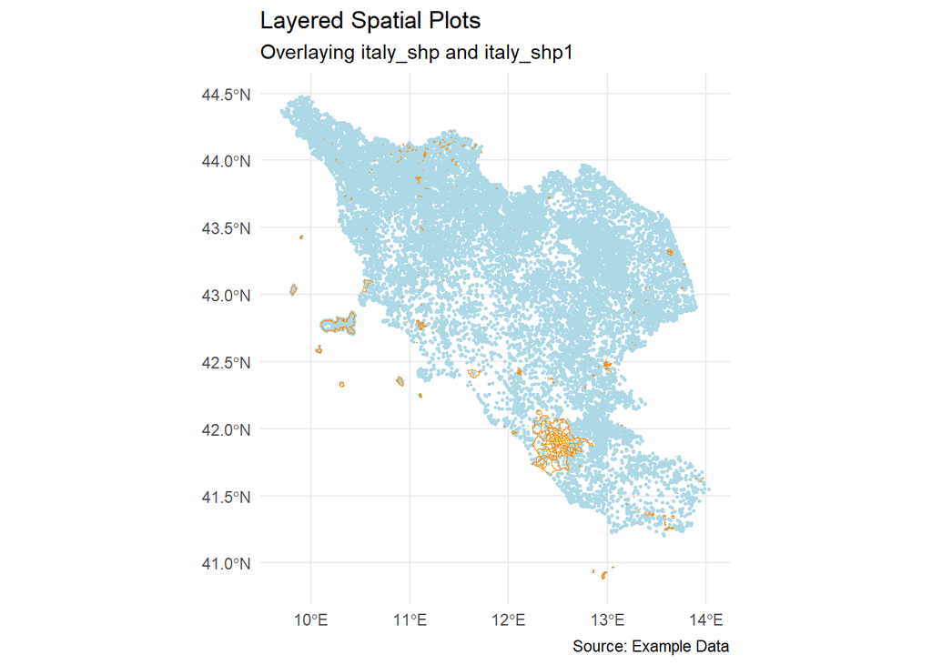

```r
# Layer both shapefiles on the same map
ggplot() +
  geom_sf(data = italy_shp, fill = "transparent", color = "lightblue", size = 0.5) +
  geom_sf(data = italy_shp1, fill = "transparent", color = "darkorange", size = 0.5) +
  theme_minimal() +
  labs(title = "Layered Spatial Plots",
       subtitle = "Overlaying italy_shp and italy_shp1",
       caption = "Source: Example Data") +
  theme(legend.position = "bottom")
```